# Sell-through Trend Analysis

Audrey Chen

2018/5/30

## Total ST of each pattern since 2015

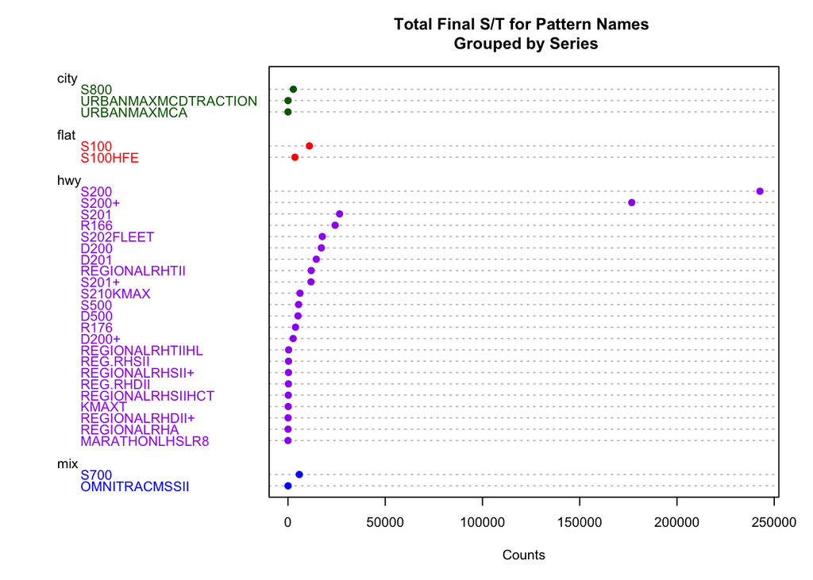

> Most patterns fall in the category of **hwy**. Sales of **S200** and **S200+** are far higher than other patterns.

## Comparison of Total ST’s of each year for 4 series.

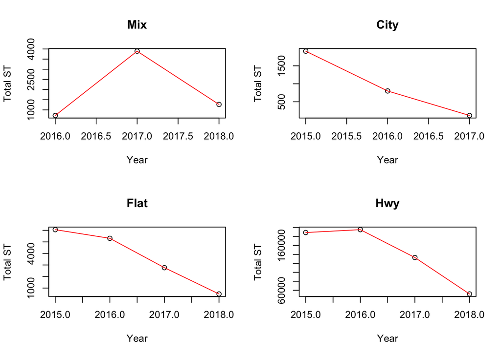

## Trend of ST

> The following scatter plots show how the product of different patterns, from the same series, contributes to the total ST in each year.

### Series 1 - flat

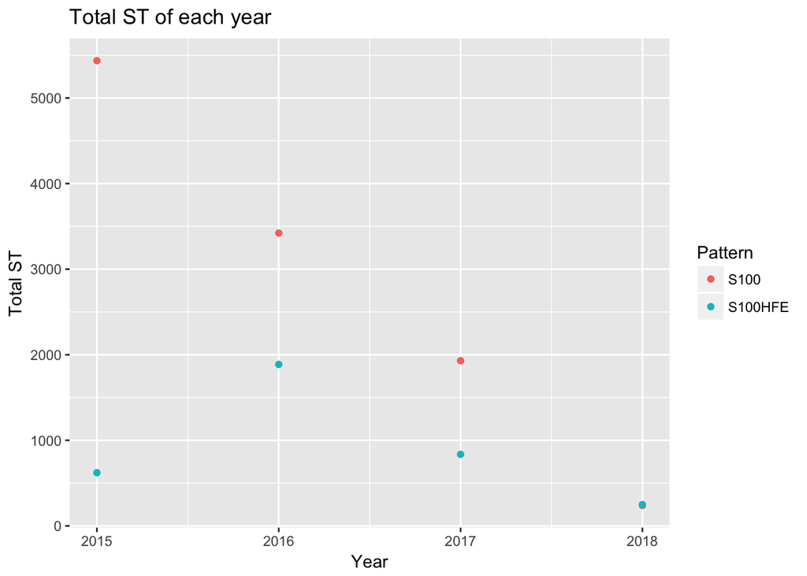

> In the serious of flat, S100 has got much less popular. The ST of S100HFE has a peak in 2016.

### Series 2 - mix

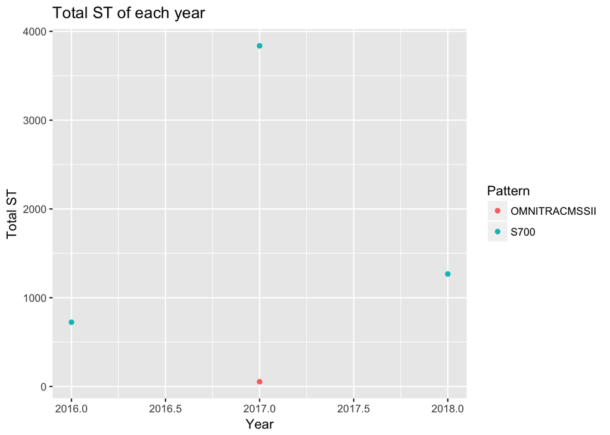

### Series 3 - city

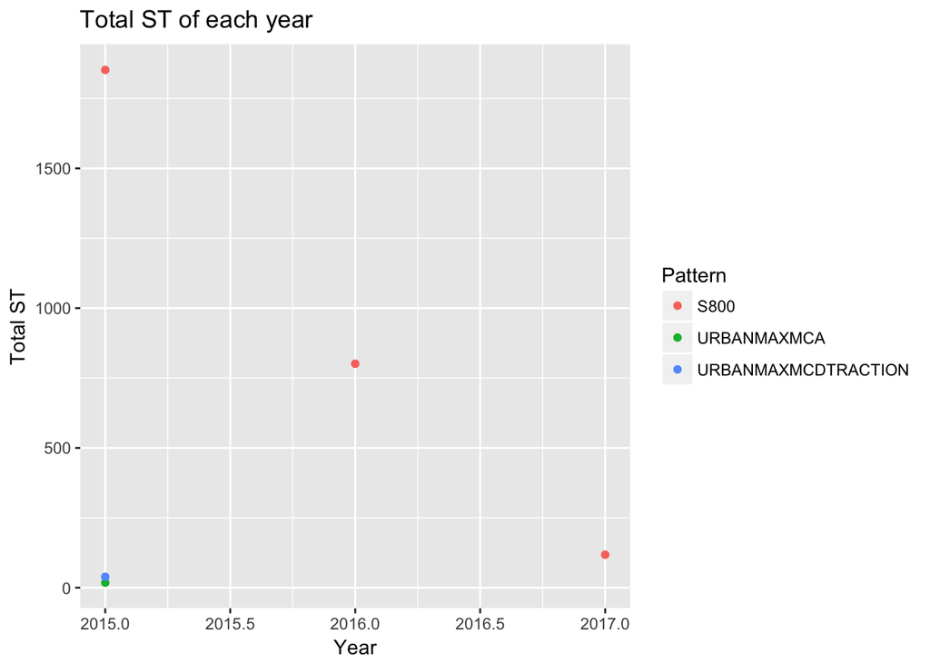

> Not popular. No data from this year. May be related with the market itself.

### Series 4 - high way

|  | Pattern | Year | total |
| --- | --- | --- | --- |
| 1 | D200 | 2015 | 12110 |
| 2 | D200 | 2016 | 3292 |
| 3 | D200 | 2017 | 1585 |
| 4 | D200 | 2018 | 182 |
| 5 | D200+ | 2016 | 597 |
| 6 | D200+ | 2017 | 1301 |
| 7 | D200+ | 2018 | 783 |
| 8 | D201 | 2015 | 5060 |
| 9 | D201 | 2016 | 4211 |
| 10 | D201 | 2017 | 4340 |

[output cut: 52 more lines]

#### 3 sub-categories (driving, trailer, steering)

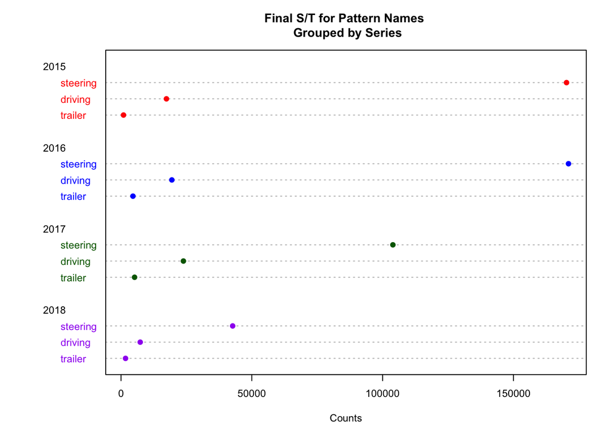

> **Steering** tires: The ST from 2015 to 2017 has been decreasing. The ST of this year has almost reach half ST of 2017. **Driving** tires: The ST has been increasing. But the ST of this year does not seem satisfying. **Trailer** tires: The least popular series.

##### The decreasing ST might be related with the decreasing number of distributors, as shown below.

```
## [1] 63
```

```
## [1] 45
```

```
## [1] 30
```

```
## [1] 27
```

##### Therefore, we pick 9 distributors that have been cooperated with Goodyear from 2015 to 2018.

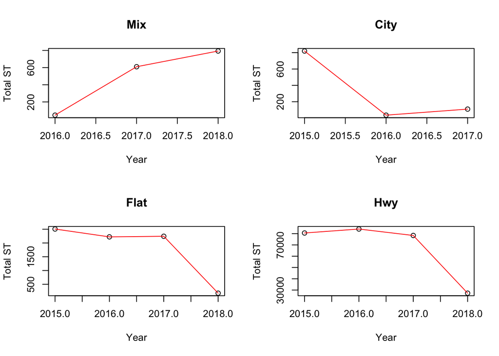

> The trend of ST is slightly different from plots above.

#### Among these 9 distributors, the number retailers that have sold tires from the series of flat of 2015-2018.

```
## [1] 58
```

```
## [1] 93
```

```
## [1] 66
```

```
## [1] 11
```

> 11 retailers in 2018.

#### Among these 9 distributors, the number of retailers that have sold tires from the series of hwy of 2015-2018

```
## [1] 556
```

```
## [1] 545
```

```
## [1] 558
```

```
## [1] 364
```

> ~200 less retailers in 2018.

```
## character(0)
```

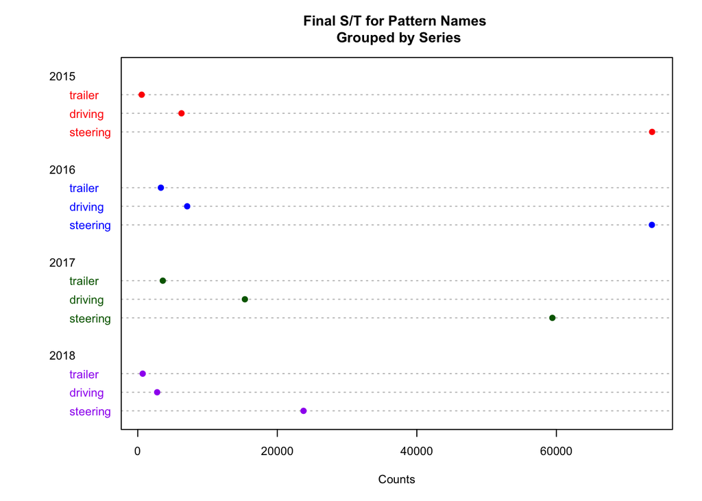

> We could pay attention to the sales of the driving series among these 9 distributors.